# Lesson 14: Inference for Several Means (ANOVA)

Preparation

- Word Document
- PDF Document

## Solutions

Problem

Part

Solution

1

-

$H_o: \text{All the means are equal}$  
$H_a: \text{One or more of the means differs from the others}$

2

-

The rule is if the largest variance is not four times the smallest variance, then we will conclude that the variances are equal.

3

-

Answers may vary, but should include that we are now dealing with more than 2 means.

4

A

Is the mean age at death different from any of the three categories of writers (novelists, poets, and nonfictions writers).

4

B

$H_o: \text{All the means are equal}$  
$H_a: \text{One or more of the means differs from the others}$

5

-

We do not know exactly how the data was collected, we only know that they looked at the ages at death for female writers in North America.

6

-

Students should have a paragraph that includes the following summary statistics.  
**Novelist:** $n = 67$, $\bar{x} = 71.448$, $s = 13.052$  
**Poets:** $n = 32$, $\bar{x} = 63.188$, $s = 17.297$  
**Nonfiction:** $n = 24$, $\bar{x} = 76.875$, $s = 14.097$  
They should also include boxplots for each sample as their graphs.

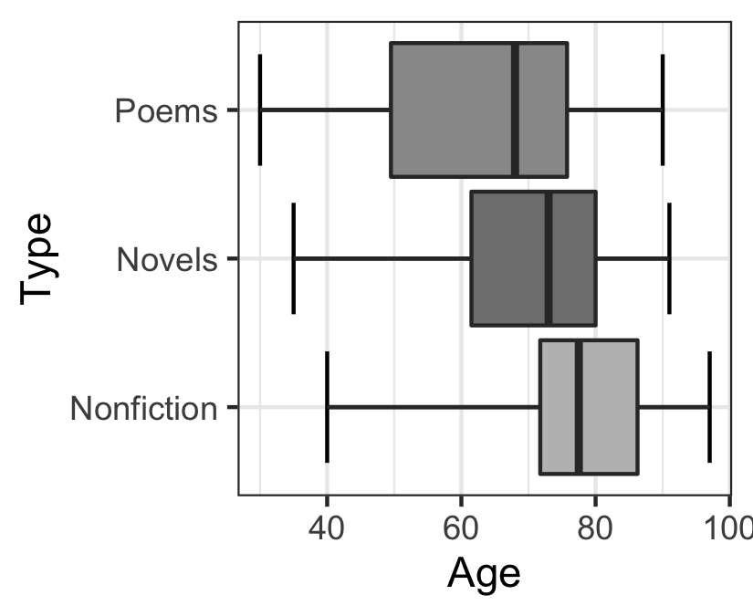

7

A

ANOVA test of several means.

7

B

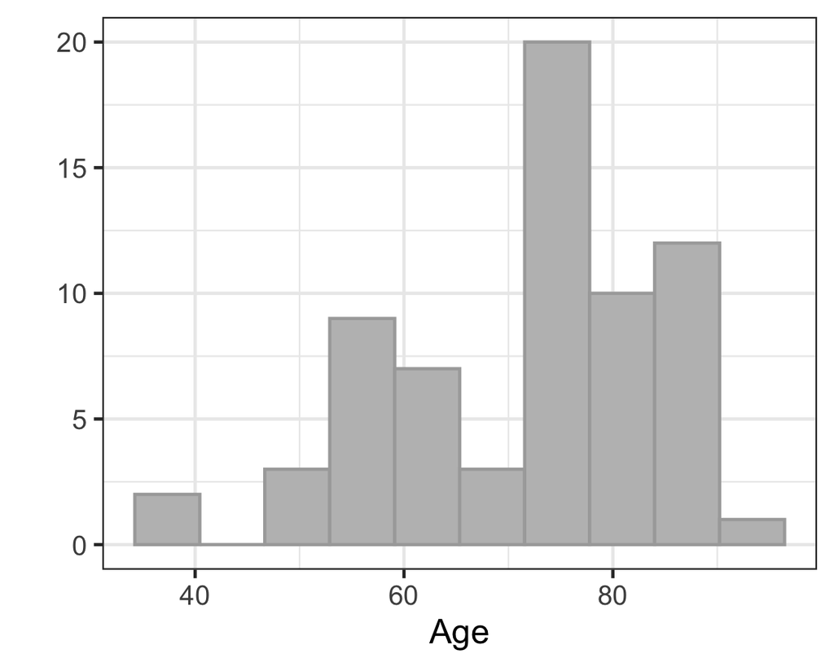

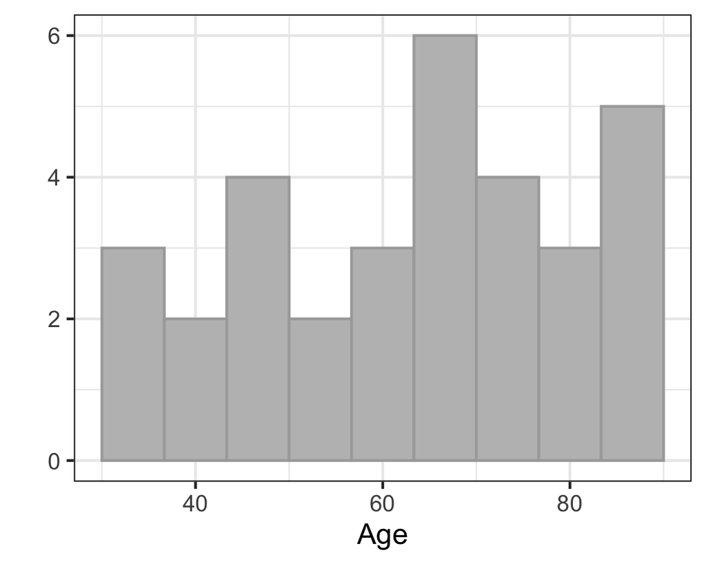

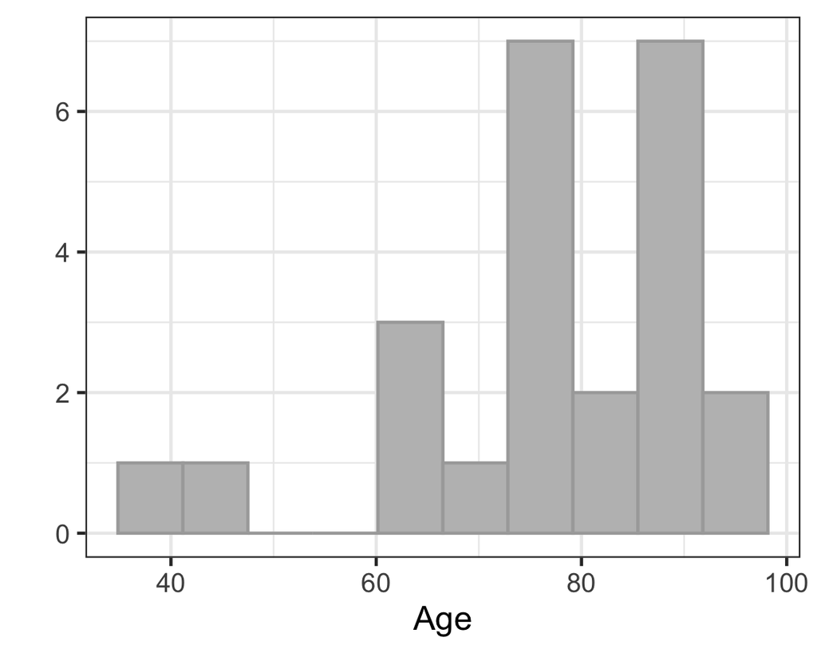

The variances for each group are equal: 299.186 is not four times 170.354 so we assume that the variances are equal.

7

C

$\text{F statistic}=6.563$

7

D

$df=2, 120$

7

E

$\text{P-value} =0.002<0.05$

7

F

We reject the null hypothesis

7

G

We have sufficient evidence to say that at least one of the mean ages of death of writers is different from the rest of the mean death ages for the other categories of writers.

8

Answers may vary